```python
from matplotlib.colors import ListedColormap

def plot_decision_regions(X, y, classifier, resolution=0.02):

    # setup marker generator and color map
    markers = ('s', '*', 'o', '^', 'v', '*')
    colors = ('red', 'blue', 'lightgreen', 'gray', 'cyan')
    cmap = ListedColormap(colors[:len(np.unique(y))])

    # plot the decision surface
    x1_min, x1_max = X[:, 0].min() - 1, X[:, 0].max() + 1
    x2_min, x2_max = X[:, 1].min() - 1, X[:, 1].max() + 1
    xx1, xx2 = np.meshgrid(np.arange(x1_min, x1_max, resolution),
                           np.arange(x2_min, x2_max, resolution))
    Z = classifier.predict(np.array([xx1.ravel(), xx2.ravel()]).T)
    Z = Z.reshape(xx1.shape)
    plt.contourf(xx1, xx2, Z, alpha=0.3, cmap=cmap)
    plt.xlim(xx1.min(), xx1.max())
    plt.ylim(xx2.min(), xx2.max())

    # plot class examples
    for idx, cl in enumerate(np.unique(y)):
        plt.scatter(x=X[y == cl, 0],
                    y=X[y == cl, 1],
                    alpha=0.8,
                    c=colors[idx],
                    marker=markers[idx],
                    label=cl,
                    edgecolor='black')
```

# Discesa del gradiente stocastica

La versione che conosciamo dell'algoritmo è detta *batch* in quanto calcola il gradiente tutto in una volta.

**Criticità dell'algoritmo di discesa del gradiente**:

L'aggiornamento dei pesi viene fatto nel seguente modo

```
self.w_[1:] += self.eta * X.T.dot(errors)
```

il che richiede l'intera matrice `X` che, nel caso questa sia molto grande, può rappresentare un problema di performance.

Con la *discesa del gradiente stocastica*, i pesi vengono aggiornati uno alla volta nel seguente modo:

```
for xj, yj in zip(X, y):
                net_input = self.net_input(xj)
                output = self.activation(net_input)
                error = (yj - output)
                self.w_[1:] += self.eta * xj*error
```

Il che non richiede la presenza dell'intera matrice `X` in memoria. Inoltre questo approccio permette anche l'addestramento *on-line*: il fitting può continuare con l'arrivo di altri dati di addestramento.

```python
import numpy as np
import matplotlib.pyplot as plt
import pandas as pd
import os

class LogisticRegression(object):
    """Logistic Regression Classifier using gradient descent.

    Parameters
    ------------
    eta : float
      Learning rate (between 0.0 and 1.0)
    n_iter : int

      Passes over the training dataset.
    random_state : int
      Random number generator seed for random weight
      initialization.


    Attributes
    -----------
    w_ : 1d-array
      Weights after fitting.
    cost_ : list
      Logistic cost function value in each epoch.

    """
    def __init__(self, eta=0.05, n_iter=50, random_state=1, fit="sfit", tol=1e-4):
        self.eta = eta
        self.n_iter = n_iter
        self.random_state = random_state
        self.fit_method = fit
        self.last_cost = None
        self.tol = tol
        self.verbose = True

    def fit(self, X, y):
        if self.fit_method == 'sfit':
            return self.sfit(X, y)
        elif self.fit_method == 'bfit':
            return self.bfit(X, y)
        else:
            raise ValueError('I metodi accettati sono bfit e sfit')


    def bfit(self, X, y):
        """ Fit training data.

        Parameters
        ----------
        X : {array-like}, shape = [n_examples, n_features]
          Training vectors, where n_examples is the number of examples and
          n_features is the number of features.
        y : array-like, shape = [n_examples]
          Target values.

        Returns
        -------
        self : object

        """
        rgen = np.random.RandomState(self.random_state)
        self.w_ = rgen.normal(loc=0.0, scale=0.01, size=1 + X.shape[1])

        for i in range(self.n_iter):
            net_input = self.net_input(X)
            output = self.activation(net_input)
            epsilon = 1e-15
            output = np.clip(output, epsilon, 1 - epsilon)
            errors = (y - output)
            self.w_[1:] += self.eta * X.T.dot(errors)
            self.w_[0] += self.eta * errors.sum()

            # note that we compute the logistic `cost` now
            # instead of the sum of squared errors cost

            cost = -y.dot(np.log(output)) - ((1 - y).dot(np.log(1 - output)))
            if self.last_cost != None and abs(cost - self.last_cost) < self.tol:
                if self.verbose:
                    print('Num. iterations', i)
                break
            self.last_cost = cost

        return self

    def sfit(self, X, y):
        """ Fit training data.

        Parameters
        ----------
        X : {array-like}, shape = [n_examples, n_features]
          Training vectors, where n_examples is the number of examples and
          n_features is the number of features.
        y : array-like, shape = [n_examples]
          Target values.

        Returns
        -------
        self : object

        """
        rgen = np.random.RandomState(self.random_state)
        self.w_ = rgen.normal(loc=0.0, scale=0.01, size=1 + X.shape[1])

        '''
        for i in range(self.n_iter):
            net_input = self.net_input(X)
            output = self.activation(net_input)
            errors = (y - output)
            self.w_[1:] += self.eta * X.T.dot(errors)
            self.w_[0] += self.eta * errors.sum()

            # note that we compute the logistic `cost` now
            # instead of the sum of squared errors cost
            cost = -y.dot(np.log(output)) - ((1 - y).dot(np.log(1 - output)))
            self.cost_.append(cost)
        '''

        for i in range(self.n_iter):
            cost = 0
            for xj, yj in zip(X, y):
                net_input = self.net_input(xj)
                output = self.activation(net_input)
                error = (yj - output)
                self.w_[1:] += self.eta * xj*error
                self.w_[0] += self.eta * error

                # note that we compute the logistic `cost` now
                # instead of the sum of squared errors cost
                cost += -yj*(np.log(output)) - ((1 - yj)*(np.log(1 - output)))
                if self.last_cost != None and abs(cost - self.last_cost) < self.tol:
                    if self.verbose:
                        print('Num. iterations', i)
                    return self

                self.last_cost = cost

        return self

    def net_input(self, X):
        """Calculate net input"""
        return np.dot(X, self.w_[1:]) + self.w_[0]

    def activation(self, z):
        """Compute logistic sigmoid activation"""
        return 1. / (1. + np.exp(-np.clip(z, -700, 700)))
        #return 1. / (1. + np.exp(-z))

    def predict(self, X):
        """Return class label after unit step"""
        return np.where(self.net_input(X) >= 0.0, 1, 0)
        # equivalent to:
        # return np.where(self.activation(self.net_input(X)) >= 0.5, 1, 0)
```

```python
s = os.path.join('dataset', 'iris.data')
df = pd.read_csv(s,
                 header=None,
                 encoding='utf-8')

# [0:50] iris-setosa
# [50:100] iris-versicolor
# [100:150] iris-virginica
y = df.iloc[50:, 4].values
y = np.where(y == 'Iris-versicolor', 1, 0)

# extract sepal length and petal length
X = df.iloc[50:, [0, 2]].values
```

## Esempi

#### Versione batch

```
Batch
 	Accuratezza: 0.9
	Secondi: 0.22112655639648438
```

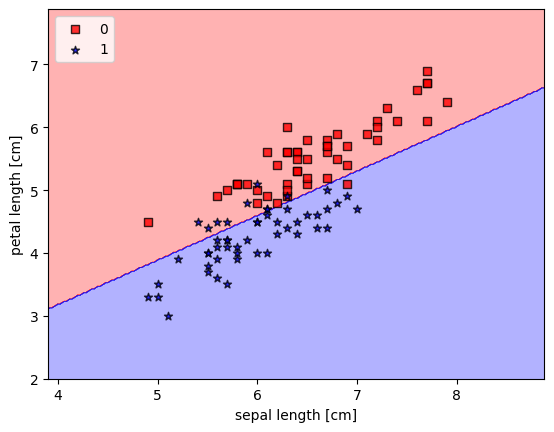

```python
from time import time

start_time = time()
lgrg = LogisticRegression(n_iter=1000, eta=0.0001, random_state=1, fit='bfit').fit(X, y)
end_time = time()
accuracy = np.mean(lgrg.predict(X) == y)
print('Batch\n', '\tAccuratezza:', accuracy, '\n\tSecondi:', end_time-start_time)

plot_decision_regions(X, y, classifier=lgrg)

plt.xlabel('sepal length [cm]')
plt.ylabel('petal length [cm]')
plt.legend(loc='upper left')
```

#### Versione stocastica

```
Batch
 	Accuratezza: 0.9
	Secondi: 10.88075566291809
```

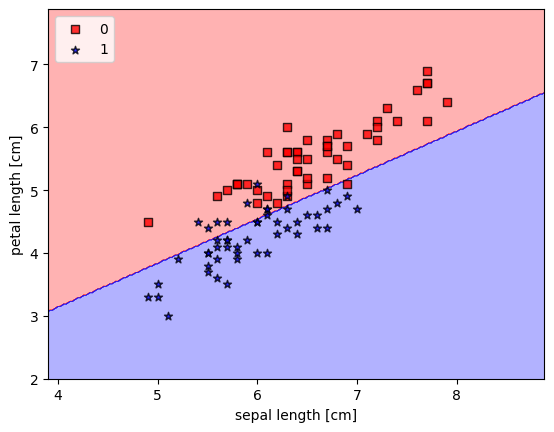

```python
start_time = time()
lgrg = LogisticRegression(n_iter=1000, eta=0.0001, random_state=1, fit='sfit').fit(X, y)
end_time = time()
accuracy = np.mean(lgrg.predict(X) == y)
print('Batch\n', '\tAccuratezza:', accuracy, '\n\tSecondi:', end_time-start_time)

plot_decision_regions(X, y, classifier=lgrg)

plt.xlabel('sepal length [cm]')
plt.ylabel('petal length [cm]')
plt.legend(loc='upper left')
```

Sebbene la trattazione precedente faccia intendere che la discesa del gradiente stocastica abbia prestazioni migliori, da questo esempio non si evince, anzi! Questo perché abbiamo sostituito le operazioni su matrici eseguite da `numpy` a livello di array con un ciclo in Python puro che, tra le altre cose, non sfrutta il parallelismo dei multi-core.

L'uso di Python puro + numpy non consente di beneficiare delle proprietà positive della versione stocastica dell'algoritmo. Meglio usare librerie specializzate come `sklearn`.

Aumentiamo la scala della seconda feature.

```
Batch
 	Accuratezza: 0.5
	Secondi: 0.22248148918151855
```

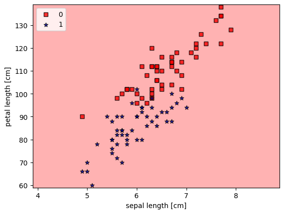

```python
X_curr = X.copy()
X_curr[:,1] *= 20

start_time = time()
lgrg = LogisticRegression(n_iter=1000, eta=0.0001, random_state=1, fit='bfit').fit(X_curr, y)
end_time = time()
accuracy = np.mean(lgrg.predict(X_curr) == y)
print('Batch\n', '\tAccuratezza:', accuracy, '\n\tSecondi:', end_time-start_time)

plot_decision_regions(X_curr, y, classifier=lgrg)

plt.xlabel('sepal length [cm]')
plt.ylabel('petal length [cm]')
plt.legend(loc='upper left')
```

1000 iterazioni non bastano, provare con 10000

# Standardizzazione

Livella i valori delle features portandole tutte sulla stessa scala, questo elimina il problema delle features troppo influenti in quanto su scale maggiori rispetto alle altre.

Sia $x$ un vettore delle features di media $\mu$ e deviazione standard $\sigma$ allora la **z-score normalization**

$$ x' = \frac{x-\mu}{\sigma} $$

definisce una nuova feature che ha media $0$ e diviazione standard $1$.

```python
'''
X_std = np.copy(X)
X_std[:, 0] = (X[:, 0] - X[:, 0].mean()) / X[:, 0].std()
X_std[:, 1] = (X[:, 1] - X[:, 1].mean()) / X[:, 1].std()
'''

# oppure
X_std = (X-X.mean(0))/X.std(0) # i valore 0 del parametri indica media e standard deviation sulle colonne
```

```python
X_curr = X_std

start_time = time()
lgrg = LogisticRegression(n_iter=1000, eta=0.001, random_state=1, fit='bfit').fit(X_curr, y)
end_time = time()
accuracy = np.mean(lgrg.predict(X_curr) == y)
print('Batch, accuratezza', accuracy, 'Secondi:', end_time-start_time)
```

```
Batch, accuratezza 0.94 Secondi: 0.22205781936645508
```

# Un esempio più completo

[Forest Cover Type](https://www.kaggle.com/datasets/uciml/forest-cover-type-dataset)

[Descrizione features](https://www.kaggle.com/c/forest-cover-type-prediction/overview)

## Descrizione del Dataset

L'area di studio comprende quattro aree selvagge situate nella **Roosevelt National Forest**, nel nord del **Colorado**.  
Ogni osservazione rappresenta un'area di **30m x 30m**. L'obiettivo è prevedere un valore intero che classifica il **tipo di copertura forestale**.

### Tipi di Copertura Forestale

1. **Abete rosso/Abete di Douglas** (*Spruce/Fir*)
2. **Pino Lodgepole** (*Lodgepole Pine*)
3. **Pino Ponderosa** (*Ponderosa Pine*)
4. **Pioppo/Cottonwood-Salice** (*Cottonwood/Willow*)
5. **Pioppo Tremulo** (*Aspen*)
6. **Abete di Douglas** (*Douglas-fir*)
7. **Krummholz** (vegetazione contorta di alta quota)

## Caratteristiche del Dataset (Features)

- **Elevation** - Altitudine in metri
- **Aspect** - Orientamento in gradi azimutali
- **Slope** - Inclinazione in gradi
- **Horizontal_Distance_To_Hydrology** - Distanza orizzontale dalla fonte d'acqua più vicina
- **Vertical_Distance_To_Hydrology** - Distanza verticale dalla fonte d'acqua più vicina
- **Horizontal_Distance_To_Roadways** - Distanza orizzontale dalla strada più vicina
- **Hillshade_9am** *(0-255)* - Livello di ombreggiatura alle 9:00 nel solstizio d'estate
- **Hillshade_Noon** *(0-255)* - Livello di ombreggiatura a mezzogiorno nel solstizio d'estate
- **Hillshade_3pm** *(0-255)* - Livello di ombreggiatura alle 15:00 nel solstizio d'estate
- **Horizontal_Distance_To_Fire_Points** - Distanza orizzontale dal punto di accensione degli incendi
- **Wilderness_Area** *(4 colonne binarie, 0 = assente, 1 = presente)* - Indica l'area naturale protetta
- **Soil_Type** *(40 colonne binarie, 0 = assente, 1 = presente)* - Indica il tipo di suolo
- **Cover_Type** *(valori interi da 1 a 7)* - Tipo di copertura forestale (target da prevedere)

## Aree Naturali Protette (Wilderness Areas)

1. **Rawah Wilderness Area**
2. **Neota Wilderness Area**
3. **Comanche Peak Wilderness Area**
4. **Cache la Poudre Wilderness Area**

## Tipi di Suolo (Soil Types - 40 Categorie)

### 1-10

1. **Cathedral family** - Complesso di rocce affioranti, estremamente sassoso
2. **Vanet - Ratake families complex** - Molto sassoso
3. **Haploborolis** - Complesso di rocce affioranti, ghiaioso
4. **Ratake family** - Complesso di rocce affioranti, ghiaioso
5. **Vanet family** - Complesso di rocce affioranti, ghiaioso
6. **Vanet - Wetmore families** - Complesso di rocce affioranti, sassoso
7. **Gothic family**
8. **Supervisor - Limber families complex**
9. **Troutville family** - Molto sassoso
10. **Bullwark - Catamount families** - Complesso di rocce affioranti, ghiaioso

### 11-20

11. **Bullwark - Catamount families** - Terreno roccioso, ghiaioso
12. **Legault family** - Terreno roccioso, sassoso
13. **Catamount family** - Complesso di rocce e Bullwark, ghiaioso
14. **Pachic Argiborolis - Aquolis complex**
15. **Non specificato nella USFS Soil and ELU Survey**
16. **Cryaquolis - Cryoborolis complex**
17. **Gateview family - Cryaquolis complex**
18. **Rogert family** - Molto sassoso
19. **Typic Cryaquolis - Borohemists complex**
20. **Typic Cryaquepts - Typic Cryaquolls complex**

### 21-30

21. **Typic Cryaquolls - Leighcan family, substrato till**
22. **Leighcan family, substrato till, estremamente roccioso**
23. **Leighcan family, substrato till - Typic Cryaquolls complex**
24. **Leighcan family, estremamente sassoso**
25. **Leighcan family, caldo, estremamente sassoso**
26. **Granile - Catamount families complex** - Molto sassoso
27. **Leighcan family, caldo - Complesso di rocce affioranti, estremamente sassoso**
28. **Leighcan family - Complesso di rocce affioranti, estremamente sassoso**
29. **Como - Legault families complex** - Estremamente sassoso
30. **Como family - Terreno roccioso - Legault family complex** - Estremamente sassoso

### 31-40

31. **Leighcan - Catamount families complex** - Estremamente sassoso
32. **Catamount family - Complesso di rocce affioranti - Leighcan family** - Estremamente sassoso
33. **Leighcan - Catamount families - Complesso di rocce affioranti** - Estremamente sassoso
34. **Cryorthents - Complesso di rocce affioranti** - Estremamente sassoso
35. **Cryumbrepts - Complesso di rocce affioranti - Cryaquepts**
36. **Bross family - Terreno roccioso - Complesso di Cryumbrepts** - Estremamente sassoso
37. **Complesso di rocce affioranti - Cryumbrepts - Cryorthents** - Estremamente sassoso
38. **Leighcan - Moran families - Cryaquolls complex** - Estremamente sassoso
39. **Moran family - Cryorthents - Leighcan family complex** - Estremamente sassoso
40. **Moran family - Cryorthents - Complesso di terreno roccioso** - Estremamente sassoso

## Esperimenti

```python
import os
import numpy as np
import pandas as pd

s = os.path.join('dataset', 'covtype.csv')
rnf_df = pd.read_csv(s, encoding='utf-8')
```

```python
rnf_df.describe()
```

|  | Elevation | Aspect | Slope | Horizontal_Distance_To_Hydrology | Vertical_Distance_To_Hydrology | Horizontal_Distance_To_Roadways | Hillshade_9am | Hillshade_Noon | Hillshade_3pm | Horizontal_Distance_To_Fire_Points | ... | Soil_Type32 | Soil_Type33 | Soil_Type34 | Soil_Type35 | Soil_Type36 | Soil_Type37 | Soil_Type38 | Soil_Type39 | Soil_Type40 | Cover_Type |
| --- | --- | --- | --- | --- | --- | --- | --- | --- | --- | --- | --- | --- | --- | --- | --- | --- | --- | --- | --- | --- | --- |
| count | 581012.000000 | 581012.000000 | 581012.000000 | 581012.000000 | 581012.000000 | 581012.000000 | 581012.000000 | 581012.000000 | 581012.000000 | 581012.000000 | ... | 581012.000000 | 581012.000000 | 581012.000000 | 581012.000000 | 581012.000000 | 581012.000000 | 581012.000000 | 581012.000000 | 581012.000000 | 581012.000000 |
| mean | 2959.365301 | 155.656807 | 14.103704 | 269.428217 | 46.418855 | 2350.146611 | 212.146049 | 223.318716 | 142.528263 | 1980.291226 | ... | 0.090392 | 0.077716 | 0.002773 | 0.003255 | 0.000205 | 0.000513 | 0.026803 | 0.023762 | 0.015060 | 2.051471 |
| std | 279.984734 | 111.913721 | 7.488242 | 212.549356 | 58.295232 | 1559.254870 | 26.769889 | 19.768697 | 38.274529 | 1324.195210 | ... | 0.286743 | 0.267725 | 0.052584 | 0.056957 | 0.014310 | 0.022641 | 0.161508 | 0.152307 | 0.121791 | 1.396504 |
| min | 1859.000000 | 0.000000 | 0.000000 | 0.000000 | -173.000000 | 0.000000 | 0.000000 | 0.000000 | 0.000000 | 0.000000 | ... | 0.000000 | 0.000000 | 0.000000 | 0.000000 | 0.000000 | 0.000000 | 0.000000 | 0.000000 | 0.000000 | 1.000000 |
| 25% | 2809.000000 | 58.000000 | 9.000000 | 108.000000 | 7.000000 | 1106.000000 | 198.000000 | 213.000000 | 119.000000 | 1024.000000 | ... | 0.000000 | 0.000000 | 0.000000 | 0.000000 | 0.000000 | 0.000000 | 0.000000 | 0.000000 | 0.000000 | 1.000000 |
| 50% | 2996.000000 | 127.000000 | 13.000000 | 218.000000 | 30.000000 | 1997.000000 | 218.000000 | 226.000000 | 143.000000 | 1710.000000 | ... | 0.000000 | 0.000000 | 0.000000 | 0.000000 | 0.000000 | 0.000000 | 0.000000 | 0.000000 | 0.000000 | 2.000000 |
| 75% | 3163.000000 | 260.000000 | 18.000000 | 384.000000 | 69.000000 | 3328.000000 | 231.000000 | 237.000000 | 168.000000 | 2550.000000 | ... | 0.000000 | 0.000000 | 0.000000 | 0.000000 | 0.000000 | 0.000000 | 0.000000 | 0.000000 | 0.000000 | 2.000000 |
| max | 3858.000000 | 360.000000 | 66.000000 | 1397.000000 | 601.000000 | 7117.000000 | 254.000000 | 254.000000 | 254.000000 | 7173.000000 | ... | 1.000000 | 1.000000 | 1.000000 | 1.000000 | 1.000000 | 1.000000 | 1.000000 | 1.000000 | 1.000000 | 7.000000 |

8 rows × 55 columns

```python
rnf_df['Cover_Type'].value_counts()
```

```
Cover_Type
2    283301
1    211840
3     35754
7     20510
6     17367
5      9493
4      2747
Name: count, dtype: int64
```

Selezioniamo solo le classi 3, 6, e 7 per classificare la classe 3 contro le altre due.

```python
rnf_df_367 = rnf_df[ rnf_df["Cover_Type"].isin([3, 6, 7]) ]

X = rnf_df_367.iloc[:, 0:6].values

y = rnf_df_367['Cover_Type'].values
y = np.where(y == 3, 1, 0)
```

```
The history saving thread hit an unexpected error (OperationalError('attempt to write a readonly database')).History will not be written to the database.
```

```python
from time import time

start_time = time()
lgrg = LogisticRegression(n_iter=1000, eta=0.0001, random_state=1, fit='bfit').fit(X, y)
end_time = time()
accuracy = np.mean(lgrg.predict(X) == y)
print('Batch\n', '\tAccuratezza:', accuracy, '\n\tSecondi:', end_time-start_time)
```

```
Batch
 	Accuratezza: 0.5674512094090804
	Secondi: 20.810638666152954
```

Proviamo con standardizzazione

```python
X_std = (X-X.mean(0))/X.std(0)

start_time = time()
lgrg = LogisticRegression(n_iter=1000, eta=0.0001, random_state=1, fit='bfit').fit(X_std, y)
end_time = time()
accuracy = np.mean(lgrg.predict(X_std) == y)
print('Batch\n', '\tAccuratezza:', accuracy, '\n\tSecondi:', end_time-start_time)
```

```
Batch
 	Accuratezza: 0.7174016378970814
	Secondi: 16.887004852294922
```

Accuratezza bassa ma il fitting ha raggiunto il numero massimo di iterazioni ammesse. Probabilmente si possono ancora aggiustare i parametri

Versione con discesa del gradiente stocastico: non eseguire, richiederebbe minuti

```
lgrg = LogisticRegression(n_iter=1000, eta=0.001, random_state=1, fit='sfit').fit(X, y)
accuracy = np.mean(lgrg.predict(X) == y)
print('Accuracy:', accuracy)
```

Proviamo con i classificatori di *scikit-learn*

```python
from sklearn.linear_model import SGDClassifier, LogisticRegression
```

```python
start_time = time()
log_reg = LogisticRegression(solver='saga', max_iter=1000, random_state=1).fit(X_std,y)
accuracy = np.mean(log_reg.predict(X_std) == y)
end_time = time()
print('Batch\n', '\tAccuratezza:', accuracy, '\n\tSecondi:', end_time-start_time)
```

```
Batch
 	Accuratezza: 0.7392131031766511
	Secondi: 1.5454866886138916
```

Per la discesa del gradiente stocastica si usa il classificatore `SGDClassifier` impostando il parametro `loss='log_loss'`

```python
start_time = time()
sgd_clf = SGDClassifier(loss='log_loss', learning_rate='optimal', max_iter=1000, random_state=1).fit(X_std,y)
accuracy = np.mean(sgd_clf.predict(X_std) == y)
end_time = time()
print('Batch\n', '\tAccuratezza:', accuracy, '\n\tSecondi:', end_time-start_time)
```

```
Batch
 	Accuratezza: 0.7420787440072796
	Secondi: 0.732144832611084
```